# The Final Project/ Group 1

Iliya Voytsyshyn, Clive Smith

2024-04-11

## Load the Libraries

Load necessary libraries for data processing and visualization

Initialize Stadia Maps API token for accessing map tiles

```r
register_stadiamaps("d67f62a2-bd90-430c-a40a-9ad6e095b888", write = FALSE)
```

## Part 0

Load and clean the main hospitals dataset

```r
hospitals <- read_csv("data/healthcare_dataset.csv")  # Load dataset
hospitals <- clean_names(hospitals)  # Clean column names
hospitals <- hospitals %>%
  select(-blood_type, -room_number)  # Remove unnecessary columns
```

Further clean and prepare the hospitals dataset for analysis

```r
hospitals_final <- hospitals %>%
  mutate(id = as.integer(factor(name))) %>%
  select(-doctor, -name) %>%
  arrange(id)  # Arrange by hospital ID for consistency
```

Load and clean the hospitals location dataset

```r
hospitals_location <- read_csv("data/hospital_locations.csv") %>%
  clean_names() %>%
  select(index, id, name, address, city, state, zip, type, status, latitude, longitude, website) %>%
  mutate(website = na_if(website, "NOT AVAILABLE"))
```

## Part 1

Extract necessary columns for Medicare cost analysis

```r
medicare_cost <- hospitals[, c("date_of_admission", "billing_amount")]
```

Split Medicare cost data into pre-COVID and post-COVID periods

```r
pre_covid <- subset(medicare_cost, date_of_admission < as.Date("2020-01-01"))
post_covid <- subset(medicare_cost, date_of_admission >= as.Date("2020-01-01"))
```

Summarize billing amount statistics for pre-COVID and post-COVID periods

```r
summary(pre_covid$billing_amount)
```

```
##    Min. 1st Qu.  Median    Mean 3rd Qu.    Max.
##    1020   13656   25059   25317   37114   49996
```

```r
summary(post_covid$billing_amount)
```

```
##    Min. 1st Qu.  Median    Mean 3rd Qu.    Max.
##    1000   13441   25300   25576   37836   49995
```

Plot Medicare cost trends over time, comparing pre-COVID and post-COVID periods

```r
combined_data <- bind_rows(pre_covid %>% mutate(period = "Pre-COVID"),
                           post_covid %>% mutate(period = "Post-COVID"))
```

Plot combined data with separate lines of regression for pre and post-COVID data

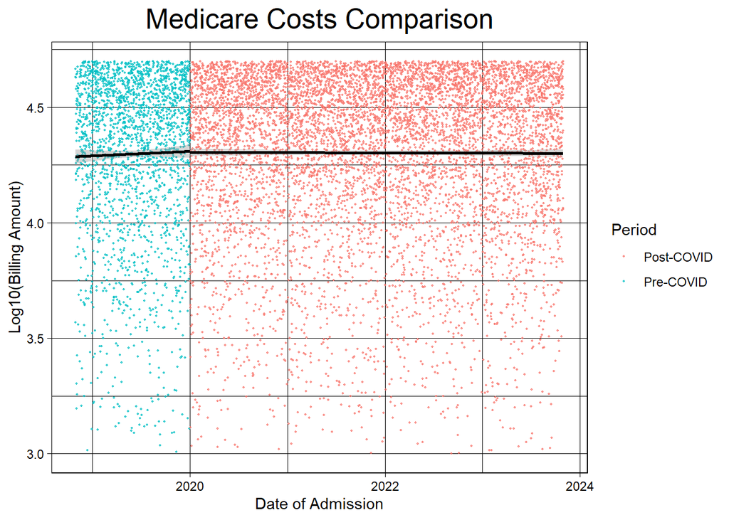

```r
combined_data %>%
  ggplot(aes(x = date_of_admission, y = log10(billing_amount), color = period)) +
  geom_point(size = 0.4, alpha=0.7) +
  geom_smooth(method = "lm", aes(group = period), se = TRUE, color="black") +
  labs(title = "Medicare Costs Comparison",
       x = "Date of Admission",
       y = "Log10(Billing Amount)",
       color = "Period") +
  theme_linedraw() +
  theme(plot.title = element_text(size = rel(1.75), hjust = 0.5))
```

Here we create a new column with price categories and visualize prices by hospitals and insurance companies and create a new column ‘price_level’ based on billing_amount ranges

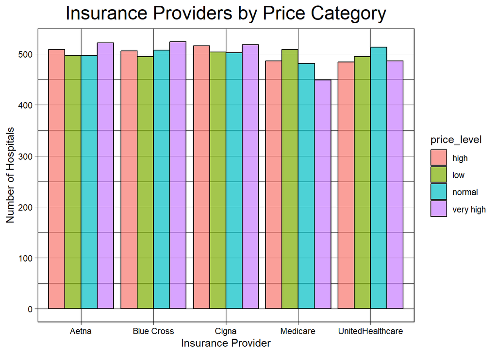

```r
hospitals_final %>%
  mutate(price_level = case_when(billing_amount < 13507 ~ "low",
                                 billing_amount >= 13507 & billing_amount <= 25258 ~ "normal",
                                 billing_amount > 25258 & billing_amount <= 37734 ~ "high",
                                 billing_amount > 37734 ~ "very high")) %>%
  count(insurance_provider, price_level) %>%
  ggplot(aes(x = insurance_provider, y = n, fill = price_level)) +
  geom_col(position = "dodge", alpha=0.7, color="black")+  # Visualize price categories by insurance providers
  theme_linedraw() +
  theme(plot.title=element_text(size = rel(1.75), hjus=0.5))+
  labs(title="Insurance Providers by Price Category",
       x="Insurance Provider", y="Number of Hospitals")
```

Visualize prices by medical conditions

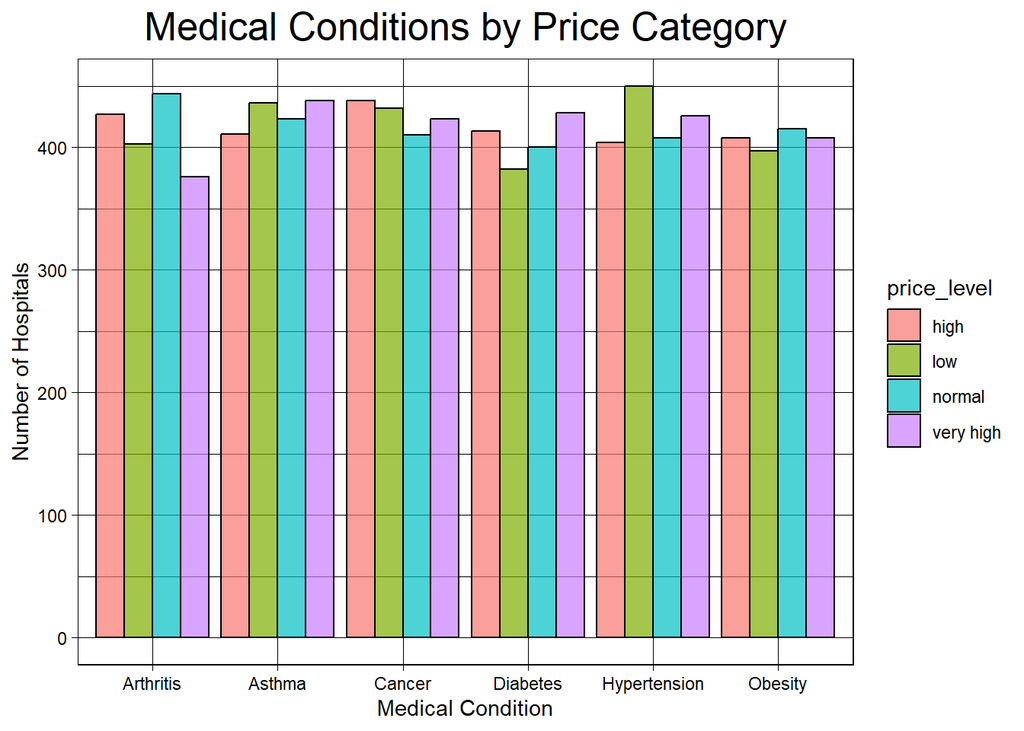

```r
hospitals_final %>%
  mutate(price_level = case_when(billing_amount < 13507 ~ "low",
                                 billing_amount >= 13507 & billing_amount <= 25258 ~ "normal",
                                 billing_amount > 25258 & billing_amount <= 37734 ~ "high",
                                 billing_amount > 37734 ~ "very high")) %>%
  count(medical_condition, price_level) %>%
  ggplot(aes(x = medical_condition, y = n, fill = price_level)) +
  geom_col(position = "dodge", alpha=0.7, color="black")+ # Visualize price categories by medical conditions
  theme_linedraw()+
  theme(plot.title=element_text(size = rel(1.75), hjus=0.5))+
  labs(title="Medical Conditions by Price Category",
       x="Medical Condition", y="Number of Hospitals")
```

## Part 2

Setting up for the app

First, we took the admit and discharge date and used them to create a variable that showed the length of each hospital stay in days. We did this using the ‘lubridate’ package.

```r
hospitals_final %>%
  mutate(discharge_date = as.Date(discharge_date),
         date_of_admission = as.Date(date_of_admission),
         time_spent = discharge_date - date_of_admission) %>%
  filter(!is.na(time_spent)) %>%
  separate(time_spent, into="length_of_stay", sep = " ") %>%
  mutate(length_of_stay=as.numeric(length_of_stay))
```

```
## # A tibble: 10,000 × 13
##      age gender medical_condition date_of_admission hospital  insurance_provider
##    <dbl> <chr>  <chr>             <date>            <chr>     <chr>
##  1    54 Female Obesity           2021-06-03        Reynolds… UnitedHealthcare
##  2    35 Female Diabetes          2023-05-12        Mata-Vega Cigna
##  3    69 Male   Cancer            2019-09-17        Petersen… Cigna
##  4    34 Male   Diabetes          2022-04-09        Silva, T… Aetna
##  5    22 Female Arthritis         2019-06-28        Lee-Clark UnitedHealthcare
##  6    79 Female Asthma            2020-12-09        Phillips… Aetna
##  7    74 Female Asthma            2021-04-07        Howard I… Blue Cross
##  8    72 Male   Obesity           2020-10-06        Morris, … Blue Cross
##  9    78 Female Hypertension      2019-09-10        Smith, F… Medicare
## 10    38 Male   Diabetes          2021-06-01        Porter, … Cigna
## # ℹ 9,990 more rows
## # ℹ 7 more variables: billing_amount <dbl>, admission_type <chr>,
## #   discharge_date <date>, medication <chr>, test_results <chr>, id <int>,
## #   length_of_stay <dbl>
```

Afterwards, we made a new variable measuring the quality of each hospital by multiplying the length of stay with billing amount. We decided that hospitals with a lower length of stay and billing amount were considered higher quality, so the lower the numerical value for hospital quality, the better the hospital. We realize that this isn’t necessarily the best metric for evaluating the quality of different hospitals, but we decided that this was the best way to do it, given the data we had.

```r
hospitals_final %>%
  mutate(discharge_date = as.Date(discharge_date),
         date_of_admission = as.Date(date_of_admission),
         time_spent = discharge_date - date_of_admission) %>%
  filter(!is.na(time_spent)) %>%
  separate(time_spent, into="length_of_stay", sep = " ") %>%
  mutate(length_of_stay=as.numeric(length_of_stay)) %>%
  mutate(hospital_quality=log10(length_of_stay*billing_amount))
```

```
## # A tibble: 10,000 × 14
##      age gender medical_condition date_of_admission hospital  insurance_provider
##    <dbl> <chr>  <chr>             <date>            <chr>     <chr>
##  1    54 Female Obesity           2021-06-03        Reynolds… UnitedHealthcare
##  2    35 Female Diabetes          2023-05-12        Mata-Vega Cigna
##  3    69 Male   Cancer            2019-09-17        Petersen… Cigna
##  4    34 Male   Diabetes          2022-04-09        Silva, T… Aetna
##  5    22 Female Arthritis         2019-06-28        Lee-Clark UnitedHealthcare
##  6    79 Female Asthma            2020-12-09        Phillips… Aetna
##  7    74 Female Asthma            2021-04-07        Howard I… Blue Cross
##  8    72 Male   Obesity           2020-10-06        Morris, … Blue Cross
##  9    78 Female Hypertension      2019-09-10        Smith, F… Medicare
## 10    38 Male   Diabetes          2021-06-01        Porter, … Cigna
## # ℹ 9,990 more rows
## # ℹ 8 more variables: billing_amount <dbl>, admission_type <chr>,
## #   discharge_date <date>, medication <chr>, test_results <chr>, id <int>,
## #   length_of_stay <dbl>, hospital_quality <dbl>
```

```r
hospitals_final %>%
  mutate(discharge_date = as.Date(discharge_date),
         date_of_admission = as.Date(date_of_admission),
         time_spent = discharge_date - date_of_admission) %>%
  filter(!is.na(time_spent)) %>%
  separate(time_spent, into="length_of_stay", sep = " ") %>%
  mutate(length_of_stay=as.numeric(length_of_stay)) %>%
  mutate(hospital_quality=log10(length_of_stay*billing_amount)) %>%
  arrange(hospital_quality) %>%
  filter(medical_condition=="Cancer") %>%
  select(hospital, hospital_quality, admission_type, medical_condition) %>%
  head(5)
```

```
## # A tibble: 5 × 4
##   hospital                     hospital_quality admission_type medical_condition
##   <chr>                                   <dbl> <chr>          <chr>
## 1 Lawson Inc                               3.12 Urgent         Cancer
## 2 Myers, Randall and Williams              3.18 Elective       Cancer
## 3 Kaufman LLC                              3.19 Urgent         Cancer
## 4 Mcdaniel, Russell and Watki…             3.57 Urgent         Cancer
## 5 Jackson Inc                              3.65 Urgent         Cancer
```

```r
hospitals_final %>%
  mutate(discharge_date = as.Date(discharge_date),
         date_of_admission = as.Date(date_of_admission),
         time_spent = discharge_date - date_of_admission) %>%
  filter(!is.na(time_spent)) %>%
  separate(time_spent, into="length_of_stay", sep = " ") %>%
  mutate(length_of_stay=as.numeric(length_of_stay)) %>%
  mutate(hospital_quality=log10(length_of_stay*billing_amount)) %>%
  arrange(hospital_quality) %>%
  filter(medical_condition=="Arthritis") %>%
  select(hospital, hospital_quality, admission_type, medical_condition) %>%
  head(5)
```

```
## # A tibble: 5 × 4
##   hospital                  hospital_quality admission_type medical_condition
##   <chr>                                <dbl> <chr>          <chr>
## 1 Melendez, Owens and Patel             3.43 Emergency      Arthritis
## 2 George Group                          3.53 Urgent         Arthritis
## 3 Lopez-Doyle                           3.66 Elective       Arthritis
## 4 Miller-Nichols                        3.70 Urgent         Arthritis
## 5 Franklin LLC                          3.72 Emergency      Arthritis
```

```r
hospitals_final %>%
  mutate(discharge_date = as.Date(discharge_date),
         date_of_admission = as.Date(date_of_admission),
         time_spent = discharge_date - date_of_admission) %>%
  filter(!is.na(time_spent)) %>%
  separate(time_spent, into="length_of_stay", sep = " ") %>%
  mutate(length_of_stay=as.numeric(length_of_stay)) %>%
  mutate(hospital_quality=log10(length_of_stay*billing_amount)) %>%
  arrange(hospital_quality) %>%
  filter(medical_condition=="Asthma") %>%
  select(hospital, hospital_quality, admission_type, medical_condition) %>%
  head(5)
```

```
## # A tibble: 5 × 4
##   hospital                hospital_quality admission_type medical_condition
##   <chr>                              <dbl> <chr>          <chr>
## 1 Miller LLC                          3.01 Urgent         Asthma
## 2 Rose, Vargas and Fox                3.02 Elective       Asthma
## 3 Vega, Green and Summers             3.05 Urgent         Asthma
## 4 Montoya Inc                         3.32 Emergency      Asthma
## 5 West PLC                            3.33 Elective       Asthma
```

```r
hospitals_final %>%
  mutate(discharge_date = as.Date(discharge_date),
         date_of_admission = as.Date(date_of_admission),
         time_spent = discharge_date - date_of_admission) %>%
  filter(!is.na(time_spent)) %>%
  separate(time_spent, into="length_of_stay", sep = " ") %>%
  mutate(length_of_stay=as.numeric(length_of_stay)) %>%
  mutate(hospital_quality=log10(length_of_stay*billing_amount)) %>%
  arrange(hospital_quality) %>%
  filter(medical_condition=="Diabetes") %>%
  select(hospital, hospital_quality, admission_type, medical_condition) %>%
  head(5)
```

```
## # A tibble: 5 × 4
##   hospital                  hospital_quality admission_type medical_condition
##   <chr>                                <dbl> <chr>          <chr>
## 1 Weiss LLC                             3.09 Emergency      Diabetes
## 2 Smith Inc                             3.33 Urgent         Diabetes
## 3 White-Oneill                          3.53 Elective       Diabetes
## 4 Larson, Clay and Smith                3.59 Urgent         Diabetes
## 5 Taylor, Bullock and Scott             3.59 Elective       Diabetes
```

```r
hospitals_final %>%
  mutate(discharge_date = as.Date(discharge_date),
         date_of_admission = as.Date(date_of_admission),
         time_spent = discharge_date - date_of_admission) %>%
  filter(!is.na(time_spent)) %>%
  separate(time_spent, into="length_of_stay", sep = " ") %>%
  mutate(length_of_stay=as.numeric(length_of_stay)) %>%
  mutate(hospital_quality=log10(length_of_stay*billing_amount)) %>%
  arrange(hospital_quality) %>%
  filter(medical_condition=="Hypertension") %>%
  select(hospital, hospital_quality, admission_type, medical_condition) %>%
  head(5)
```

```
## # A tibble: 5 × 4
##   hospital                     hospital_quality admission_type medical_condition
##   <chr>                                   <dbl> <chr>          <chr>
## 1 Matthews PLC                             3.11 Urgent         Hypertension
## 2 Krueger PLC                              3.53 Urgent         Hypertension
## 3 Smith-Watkins                            3.54 Elective       Hypertension
## 4 Torres, Davis and Valdez                 3.57 Urgent         Hypertension
## 5 Alexander, Coleman and Stev…             3.58 Elective       Hypertension
```

```r
hospitals_final %>%
  mutate(discharge_date = as.Date(discharge_date),
         date_of_admission = as.Date(date_of_admission),
         time_spent = discharge_date - date_of_admission) %>%
  filter(!is.na(time_spent)) %>%
  separate(time_spent, into="length_of_stay", sep = " ") %>%
  mutate(length_of_stay=as.numeric(length_of_stay)) %>%
  mutate(hospital_quality=log10(length_of_stay*billing_amount)) %>%
  arrange(hospital_quality) %>%
  filter(medical_condition=="Obesity") %>%
  select(hospital, hospital_quality, admission_type, medical_condition) %>%
  head(5)
```

```
## # A tibble: 5 × 4
##   hospital                     hospital_quality admission_type medical_condition
##   <chr>                                   <dbl> <chr>          <chr>
## 1 Ali Inc                                  3.49 Emergency      Obesity
## 2 Burns-Brown                              3.57 Elective       Obesity
## 3 Bishop and Sons                          3.69 Emergency      Obesity
## 4 Sellers, Johnson and Wallace             3.71 Emergency      Obesity
## 5 Patel Ltd                                3.81 Emergency      Obesity
```

#Part 3

In this section, we made an app that incorporates all of the data tables shown above. It also allows you to filter by the different insurance providers in the data.

Shiny applications not supported in static R Markdown documents

## Part 4

This is the final part of the project, where we matched the hospitals shown from the app above to a different data set containing the zip codes and coordinates of hospitals around the country. The app that I (Iliya) created takes the closest matches in the hospital locations data set and puts them onto a map of the US. The biggest challenge in this part was matching the names of the hospitals in the two data sets to each other. The solution that I (Iliya) created wasn’t perfect, as the names from the data sets don’t match up exactly, but with better data, this could be fixed.

The code still has room for improvement, particularly in the accuracy of finding new hospitals, which can be enhanced to consider more than just the first word.

```r
result1 <- hospitals_final %>%
  mutate(discharge_date = as.Date(discharge_date),
         date_of_admission = as.Date(date_of_admission),
         time_spent = discharge_date - date_of_admission) %>%
  filter(!is.na(time_spent)) %>%
  separate(time_spent, into="length_of_stay", sep = " ") %>%
  mutate(length_of_stay=as.numeric(length_of_stay)) %>%
  mutate(hospital_quality=log10(length_of_stay*billing_amount)) %>%
  arrange(hospital_quality) %>%
  filter(medical_condition=="Hypertension") %>%
  select(hospital, hospital_quality, admission_type, medical_condition) %>%
  head(5) %>%
  rowwise() %>%
  mutate(
    w = strsplit(hospital, " ")[[1]][1],
    w = str_replace_all(w, "[^[:alnum:]]", " "), # these lines of code allow to pull
    combined_results = list(hospitals_location[grep(w, tolower(hospitals_location$name), ignore.case = TRUE), c("name", "zip", "latitude", "longitude")]) #this line helps to combine the output from the previus one in the sinle table
  ) %>%
  pull(combined_results) %>%
  do.call(rbind, .)
result1
```

```
## # A tibble: 3 × 4
##   name                                                    zip latitude longitude
##   <chr>                                                 <dbl>    <dbl>     <dbl>
## 1 NOVANT HEALTH MATTHEWS MEDICAL CENTER                 28105     35.1     -80.7
## 2 HOUSTON METHODIST SAN JACINTO HOSPITAL ALEXANDER CAM… 77520     29.7     -94.9
## 3 ALEXANDER HOSPITAL                                    28603     35.7     -81.3
```

Shiny applications not supported in static R Markdown documents